# Untitled

Jayne Silva; Janaina Agra; Paulo Henrique

8 de junho de 2017

# Tutorial básico para testeT no R

Olá, vamos agora aprender um passo-a-passo bem simple de funções que te ajudarão a realizar o testeT usando o R para um conjuto de amostras independentes e dependentes.

Antes de tudo, você precisará de **dados** que atendam a essa categoria de teste, aqui daremos dois exemplos de cada tipo de testeT com dados fictícios e você pode pode criar também para treinar este script.

Após “Criar” seu conjuto de dados, salve-os numa pasta e confira se o R está no diretório da pasta certa com a função:

```r
dir()
```

```
##  [1] "dados.zip"
##  [2] "introducão-ao-software-r-para-biologia-marcos-vital-ufal-2015.pdf"
##  [3] "Introducao_a_bioestatistica_para_simples.pdf"
##  [4] "markdown.html"
##  [5] "markdown.Rmd"
##  [6] "mata_caatinga.txt"
##  [7] "Mendeley-Completo.pptx"
##  [8] "microalgas.txt"
##  [9] "pratica1.txt"
## [10] "Pseudoreplicação e Concepção de Experiências Ecológicas de Campo.docx"
## [11] "Pseudoreplication and the design of ecological field experiments - Hurlbert 1984.pdf"
## [12] "script para seminário de teste T.Rmd"
## [13] "script_para_seminário_de_teste_T.Rmd"
## [14] "script_para_seminário_de_teste_T_files"
## [15] "Scripts de aula"
```

Caso não esteja, vá em arquivo, mudar diretório e escolha a pasta correta.

Agora vc cria um objeto para trabalhar os dados da pasta, use o h=T para que o R entenda que não queremos que ele leia a primeira linha da coluna como uma amostra, e sim como cabeçalho.

```r
dados<-read.table("microalgas.txt",h=T)
```

Hipótese: a abundância de microalgas terá diferença significativa entre os tratamentos. Agora, é aconselhável conferir se seu objeto está correto:

```r
summary(dados)
```

```
##    Abundancia          group
##  Min.   : 50.0   control  :7
##  1st Qu.:102.8   treatment:7
##  Median :128.5
##  Mean   :130.7
##  3rd Qu.:158.5
##  Max.   :223.0
```

Agora vamos ver se os dados tem suas variâncias homogêneas e que os dados não difiram significativamente da distribuição normal, para isso precisamos realizar o teste de Shapiro que tem como hipótese nula a normalidade dos dados.

```r
shapiro.test(dados$Abundancia[dados$group=="control"])
```

```
##
##  Shapiro-Wilk normality test
##
## data:  dados$Abundancia[dados$group == "control"]
## W = 0.90886, p-value = 0.388
```

```r
shapiro.test(dados$Abundancia[dados$group=="treatment"])
```

```
##
##  Shapiro-Wilk normality test
##
## data:  dados$Abundancia[dados$group == "treatment"]
## W = 0.94985, p-value = 0.7283
```

Vamos então finalmete ao teste T agora:

```r
t.test(dados$Abundancia~dados$group,var.equal=T, paired=T)
```

```
##
##  Paired t-test
##
## data:  dados$Abundancia by dados$group
## t = -2.8869, df = 6, p-value = 0.02781
## alternative hypothesis: true difference in means is not equal to 0
## 95 percent confidence interval:
##  -86.573242  -7.141044
## sample estimates:
## mean of the differences
##               -46.85714
```

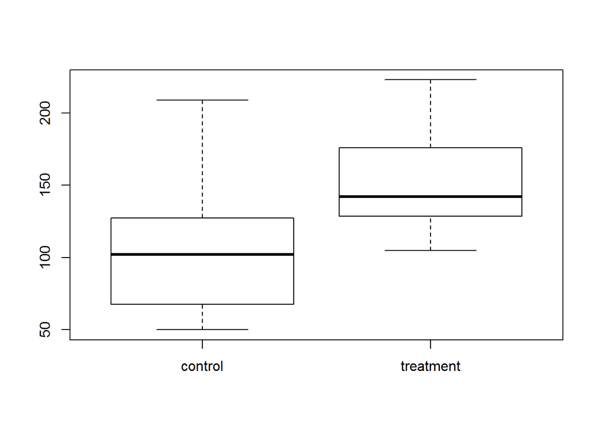

```r
boxplot(dados$Abundancia~dados$group)
```

```r
dir()
```

```
##  [1] "dados.zip"
##  [2] "introducão-ao-software-r-para-biologia-marcos-vital-ufal-2015.pdf"
##  [3] "Introducao_a_bioestatistica_para_simples.pdf"
##  [4] "markdown.html"
##  [5] "markdown.Rmd"
##  [6] "mata_caatinga.txt"
##  [7] "Mendeley-Completo.pptx"
##  [8] "microalgas.txt"
##  [9] "pratica1.txt"
## [10] "Pseudoreplicação e Concepção de Experiências Ecológicas de Campo.docx"
## [11] "Pseudoreplication and the design of ecological field experiments - Hurlbert 1984.pdf"
## [12] "script para seminário de teste T.Rmd"
## [13] "script_para_seminário_de_teste_T.Rmd"
## [14] "script_para_seminário_de_teste_T_files"
## [15] "Scripts de aula"
```

```r
dados2<-read.table("mata_caatinga.txt",h=T)

head(dados)
```

```
##   Abundancia   group
## 1        135 control
## 2         50 control
## 3        209 control
## 4         67 control
## 5         68 control
## 6        120 control
```

**Hipótese**: a riqueza significamente entre os tipos de ambientes

```r
summary(dados)
```

```
##    Abundancia          group
##  Min.   : 50.0   control  :7
##  1st Qu.:102.8   treatment:7
##  Median :128.5
##  Mean   :130.7
##  3rd Qu.:158.5
##  Max.   :223.0
```

## Agora vamos ver a normalidade

Teste de shapiro dentro do parentese do teste shapiro, coloca-se nome do objeto + $ + variavel resposta + [ nome do objeto + $ + categogia + 2 = (==) nome da categoria.

```r
shapiro.test(dados2$Riqueza [dados2$Ambiente == "caatinga"])
```

```
##
##  Shapiro-Wilk normality test
##
## data:  dados2$Riqueza[dados2$Ambiente == "caatinga"]
## W = 0.96309, p-value = 0.8205
```

```r
shapiro.test(dados2$Riqueza [dados2$Ambiente == "mata"])
```

```
##
##  Shapiro-Wilk normality test
##
## data:  dados2$Riqueza[dados2$Ambiente == "mata"]
## W = 0.94646, p-value = 0.2915
```

# Teste de Levene

```r
library(car)

leveneTest(dados2$Riqueza~dados2$Ambiente)
```

```
## Levene's Test for Homogeneity of Variance (center = median)
##       Df F value Pr(>F)
## group  1  0.0136 0.9079
##       29
```

# Depois dos resultados faz o teste T

```r
t.test(dados2$Riqueza~ dados2$Ambiente,var.equal=T)
```

```
##
##  Two Sample t-test
##
## data:  dados2$Riqueza by dados2$Ambiente
## t = -2.6874, df = 29, p-value = 0.0118
## alternative hypothesis: true difference in means is not equal to 0
## 95 percent confidence interval:
##  -11.01908  -1.49521
## sample estimates:
## mean in group caatinga     mean in group mata
##               23.60000               29.85714
```

**É isso gente** , *Obrigada*